# HW4

Wei Ping

2017年5月11日

```r
#library(dplyr)
#install.packages("ggplot")
#update.packages("ggplot")
library(ggplot2)
#library(plotly)
#library(data.table)
#require(stats)
path <- "D:/R/HW4/rawdata.csv"
rawdata <- read.table(path, header = TRUE, sep = ",")
summary(rawdata)
```

```
##                院系       總人數        男生總數       女生總數
##  工學院          :1   Min.   : 687   Min.   : 280   Min.   : 407
##  公共衛生學院    :1   1st Qu.:2232   1st Qu.: 878   1st Qu.: 662
##  文學院          :1   Median :3069   Median :1838   Median : 956
##  生命科學院      :1   Mean   :2883   Mean   :1738   Mean   :1145
##  生物資源暨農學院:1   3rd Qu.:3667   3rd Qu.:2119   3rd Qu.:1632
##  法律學院        :1   Max.   :4851   Max.   :3895   Max.   :2025
##  (Other)         :5
##     學士總數       男生學士         女生學士         碩士總數
##  Min.   : 143   Min.   :  64.0   Min.   :  79.0   Min.   : 351
##  1st Qu.:1052   1st Qu.: 504.5   1st Qu.: 260.5   1st Qu.: 700
##  Median :1795   Median : 921.0   Median : 457.0   Median : 952
##  Mean   :1503   Mean   : 858.3   Mean   : 644.6   Mean   :1019
##  3rd Qu.:2036   3rd Qu.:1167.5   3rd Qu.:1039.0   3rd Qu.:1267
##  Max.   :2371   Max.   :1683.0   Max.   :1451.0   Max.   :2018
##
##     男生碩士         女生碩士        教學成本           學士55000
##  Min.   : 116.0   Min.   :202.0   Min.   : 31423535   Min.   :0.0625
##  1st Qu.: 301.5   1st Qu.:260.0   1st Qu.:188003814   1st Qu.:0.2266
##  Median : 470.0   Median :468.0   Median :327713150   Median :0.2800
##  Mean   : 625.5   Mean   :393.7   Mean   :356156387   Mean   :0.2667
##  3rd Qu.: 786.0   3rd Qu.:508.0   3rd Qu.:502626898   3rd Qu.:0.3049
##  Max.   :1516.0   Max.   :554.0   Max.   :729103956   Max.   :0.4940
##
##    學士45000        學士35000        學士25000
##  Min.   :0.0625   Min.   :0.1928   Min.   :0.0455
##  1st Qu.:0.1829   1st Qu.:0.2575   1st Qu.:0.1371
##  Median :0.2249   Median :0.3041   Median :0.1567
##  Mean   :0.2130   Mean   :0.3640   Mean   :0.1517
##  3rd Qu.:0.2834   3rd Qu.:0.3847   3rd Qu.:0.1875
##  Max.   :0.3068   Max.   :0.6875   Max.   :0.2118
##
##  學士其他.不願提供薪資或拒答. 碩士60.001元以上  碩士40.001元至60.000元
##  Min.   :0.000000             Min.   :0.06520   Min.   :0.2845
##  1st Qu.:0.000000             1st Qu.:0.09135   1st Qu.:0.3891
##  Median :0.000000             Median :0.22670   Median :0.4503
##  Mean   :0.004591             Mean   :0.26816   Mean   :0.4531
##  3rd Qu.:0.006200             3rd Qu.:0.38775   3rd Qu.:0.4970
##  Max.   :0.018500             Max.   :0.64200   Max.   :0.6389
##
##  碩士31.001元至40.000元 碩士31.000元以下  碩士其他.不願提供薪資或拒答.
##  Min.   :0.0294         Min.   :0.00510   Min.   :0.0000
##  1st Qu.:0.0798         1st Qu.:0.02085   1st Qu.:0.0000
##  Median :0.2222         Median :0.02620   Median :0.0031
##  Mean   :0.2297         Mean   :0.03291   Mean   :0.0161
##  3rd Qu.:0.3374         3rd Qu.:0.04180   3rd Qu.:0.0106
##  Max.   :0.5690         Max.   :0.06900   Max.   :0.1118
##
```

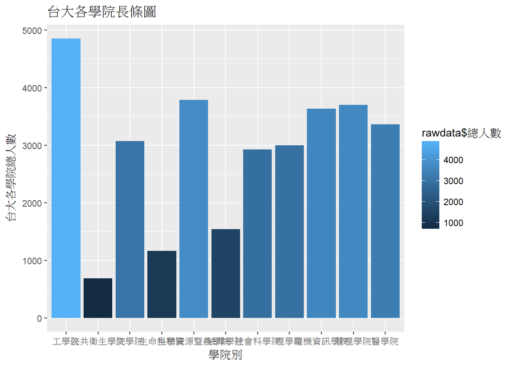

```r
depart <- c("文學院","理學院","社會科學院","醫學院","工學院","生物資源暨農學院","管理學院","公共衛生學院","電機資訊學院","法律學院","生命科學院")
# 長條圖
g <- ggplot(rawdata, aes(rawdata$院系, y = rawdata$總人數))+
  geom_bar( aes(fill = rawdata$總人數),stat = "identity") +labs( y = '台大各學院總人數', x = '學院別',title ='台大各學院長條圖')
g
```

```r
# 數值對數值分析: 總人數與總教學成本
fit <- lm(rawdata$總人數~ rawdata$教學成本 , data = rawdata)
summary(fit)
```

```
##
## Call:
## lm(formula = rawdata$總人數 ~ rawdata$教學成本, data = rawdata)
##
## Residuals:
##     Min      1Q  Median      3Q     Max
## -1101.0  -648.6  -282.1   549.4  1501.2
##
## Coefficients:
##                   Estimate Std. Error t value Pr(>|t|)
## (Intercept)      1.373e+03  5.511e+02   2.492   0.0343 *
## rawdata$教學成本 4.238e-06  1.341e-06   3.160   0.0115 *
## ---
## Signif. codes:  0 '***' 0.001 '**' 0.01 '*' 0.05 '.' 0.1 ' ' 1
##
## Residual standard error: 911.9 on 9 degrees of freedom
## Multiple R-squared:  0.526,  Adjusted R-squared:  0.4733
## F-statistic: 9.986 on 1 and 9 DF,  p-value: 0.01155
```

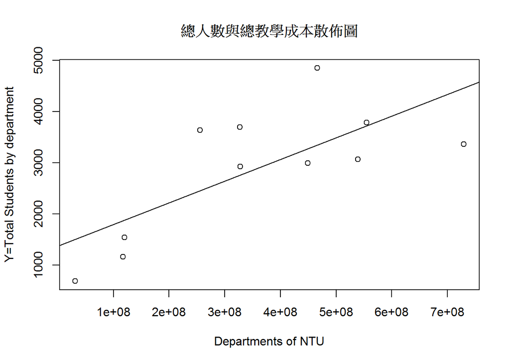

```r
plot(rawdata$教學成本,rawdata$總人數,ylab = "Y=Total Students by department", xlab = "Departments of NTU")
abline(fit)
title("總人數與總教學成本散佈圖", lwd=2)
```

繪製總人數與總教學成本的散佈圖，並畫上回歸分析的直線。 由散佈圖可以看出總人數與總教學成本有明顯的正相關。

```r
fit2 <- lm(rawdata$碩士總數 ~ rawdata$教學成本 + rawdata$碩士60.001元以上 + rawdata$碩士40.001元至60.000元 + rawdata$碩士31.001元至40.000元 + rawdata$碩士31.000元以下 + rawdata$碩士其他.不願提供薪資或拒答., data= rawdata)
summary(fit2)
```

```
##
## Call:
## lm(formula = rawdata$碩士總數 ~ rawdata$教學成本 + rawdata$碩士60.001元以上 +
##     rawdata$碩士40.001元至60.000元 + rawdata$碩士31.001元至40.000元 +
##     rawdata$碩士31.000元以下 + rawdata$碩士其他.不願提供薪資或拒答.,
##     data = rawdata)
##
## Residuals:
##        1        2        3        4        5        6        7        8
##   10.111 -171.004 -286.595    9.083  136.059  -50.248  364.386   -7.079
##        9       10       11
##   37.632 -198.418  156.074
##
## Coefficients:
##                                        Estimate Std. Error t value
## (Intercept)                          -4.913e+06  1.685e+06  -2.916
## rawdata$教學成本                      5.673e-07  7.693e-07   0.737
## rawdata$碩士60.001元以上              4.914e+06  1.685e+06   2.917
## rawdata$碩士40.001元至60.000元        4.915e+06  1.685e+06   2.917
## rawdata$碩士31.001元至40.000元        4.911e+06  1.685e+06   2.915
## rawdata$碩士31.000元以下              4.920e+06  1.682e+06   2.926
## rawdata$碩士其他.不願提供薪資或拒答.  4.917e+06  1.686e+06   2.917
##                                      Pr(>|t|)
## (Intercept)                            0.0434 *
## rawdata$教學成本                       0.5018
## rawdata$碩士60.001元以上               0.0434 *
## rawdata$碩士40.001元至60.000元         0.0434 *
## rawdata$碩士31.001元至40.000元         0.0435 *
## rawdata$碩士31.000元以下               0.0430 *
## rawdata$碩士其他.不願提供薪資或拒答.   0.0434 *
## ---
## Signif. codes:  0 '***' 0.001 '**' 0.01 '*' 0.05 '.' 0.1 ' ' 1
##
## Residual standard error: 287.5 on 4 degrees of freedom
## Multiple R-squared:  0.8705, Adjusted R-squared:  0.6762
## F-statistic: 4.481 on 6 and 4 DF,  p-value: 0.08409
```

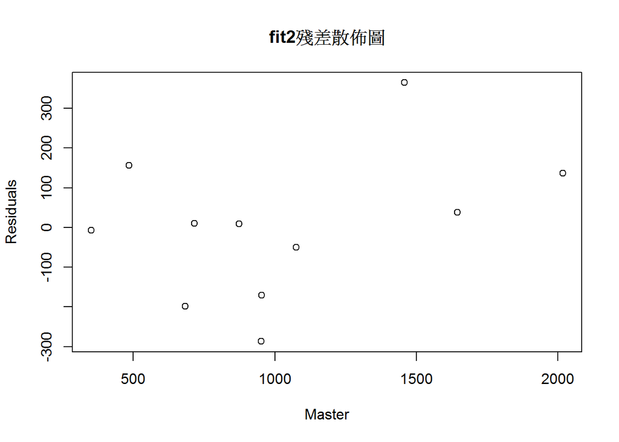

```r
plot(rawdata$碩士總數,residuals(fit2),main="fit2殘差散佈圖",xlab="Master",ylab="Residuals")
```

```r
fit3 <- lm(rawdata$碩士總數 ~ rawdata$碩士60.001元以上 + rawdata$碩士40.001元至60.000元 + rawdata$碩士31.001元至40.000元 + rawdata$碩士31.000元以下 + rawdata$碩士其他.不願提供薪資或拒答.)
summary(fit3)
```

```
##
## Call:
## lm(formula = rawdata$碩士總數 ~ rawdata$碩士60.001元以上 + rawdata$碩士40.001元至60.000元 +
##     rawdata$碩士31.001元至40.000元 + rawdata$碩士31.000元以下 +
##     rawdata$碩士其他.不願提供薪資或拒答.)
##
## Residuals:
##       1       2       3       4       5       6       7       8       9
##   89.49 -255.52 -348.34   91.56  128.12   38.76  323.54  -28.22   87.85
##      10      11
## -192.62   65.38
##
## Coefficients:
##                                      Estimate Std. Error t value Pr(>|t|)
## (Intercept)                          -5052204    1595948  -3.166   0.0249
## rawdata$碩士60.001元以上              5052493    1595843   3.166   0.0249
## rawdata$碩士40.001元至60.000元        5054429    1595998   3.167   0.0249
## rawdata$碩士31.001元至40.000元        5050426    1595954   3.165   0.0250
## rawdata$碩士31.000元以下              5055866    1593647   3.173   0.0247
## rawdata$碩士其他.不願提供薪資或拒答.  5054522    1597333   3.164   0.0250
##
## (Intercept)                          *
## rawdata$碩士60.001元以上             *
## rawdata$碩士40.001元至60.000元       *
## rawdata$碩士31.001元至40.000元       *
## rawdata$碩士31.000元以下             *
## rawdata$碩士其他.不願提供薪資或拒答. *
## ---
## Signif. codes:  0 '***' 0.001 '**' 0.01 '*' 0.05 '.' 0.1 ' ' 1
##
## Residual standard error: 274 on 5 degrees of freedom
## Multiple R-squared:  0.8529, Adjusted R-squared:  0.7058
## F-statistic: 5.798 on 5 and 5 DF,  p-value: 0.03819
```

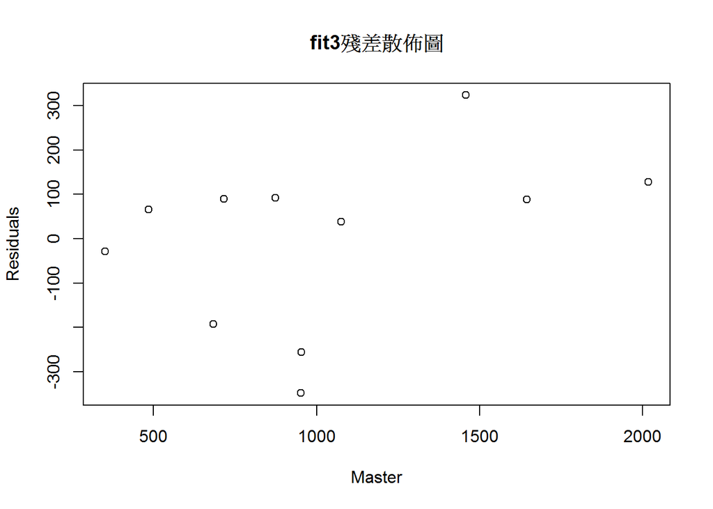

```r
plot(rawdata$碩士總數,residuals(fit3),main="fit3殘差散佈圖",xlab="Master",ylab="Residuals")
```

```r
anova(fit3)
```

```
## Analysis of Variance Table
##
## Response: rawdata$碩士總數
##                                      Df  Sum Sq Mean Sq F value  Pr(>F)
## rawdata$碩士60.001元以上              1  211147  211147  2.8114 0.15444
## rawdata$碩士40.001元至60.000元        1 1004838 1004838 13.3795 0.01463 *
## rawdata$碩士31.001元至40.000元        1   26780   26780  0.3566 0.57642
## rawdata$碩士31.000元以下              1  182384  182384  2.4285 0.17989
## rawdata$碩士其他.不願提供薪資或拒答.  1  752012  752012 10.0131 0.02497 *
## Residuals                             5  375513   75103
## ---
## Signif. codes:  0 '***' 0.001 '**' 0.01 '*' 0.05 '.' 0.1 ' ' 1
```

```r
anova(fit3, fit2)
```

```
## Analysis of Variance Table
##
## Model 1: rawdata$碩士總數 ~ rawdata$碩士60.001元以上 + rawdata$碩士40.001元至60.000元 +
##     rawdata$碩士31.001元至40.000元 + rawdata$碩士31.000元以下 +
##     rawdata$碩士其他.不願提供薪資或拒答.
## Model 2: rawdata$碩士總數 ~ rawdata$教學成本 + rawdata$碩士60.001元以上 +
##     rawdata$碩士40.001元至60.000元 + rawdata$碩士31.001元至40.000元 +
##     rawdata$碩士31.000元以下 + rawdata$碩士其他.不願提供薪資或拒答.
##   Res.Df    RSS Df Sum of Sq      F Pr(>F)
## 1      5 375513
## 2      4 330573  1     44941 0.5438 0.5018
```

根據殘差散佈圖，這個回歸模型還不夠好，因為殘差只符合三加一假設的mean = 0，而可以明顯看出未符合常態分佈。可以推論為: 1. 樣本數太少: 若採用更多年度的數據，或許能夠更準確解釋碩士人數變異。 2. 還有其他重要變數未納入考慮: fit2 與 fit3 只有分別拿碩士薪資與總教學成本作為解釋變數，但影響學士班同學就學的因素可能還有很多，例如家庭環境、人口統計變數等等。

另外，根據anova(fit2, fit3)可以看出p-value並未推翻虛無假設，因此可以推論fit2所增加的總教學成本，在碩士薪資變數不變得情況下，並未提高模型解釋度，在這個情況下可以拿掉這個變數。